[figure not shown]

# Resumen académico del año 2025: SLEP Aysén

Author

Unidad de Análisis y Monitoreo

# 1 Resumen ejecutivo

El presente informe tiene como objetivo caracterizar el desempeño académico del estudiantado del Servicio Local de Educación Pública de Aysén durante el año escolar 2025, poniendo énfasis en tres dimensiones centrales:

- Las situaciones finales de aprobación, reprobación y retiro.
- Los patrones de rendimiento académico en asignaturas y áreas de conocimiento.
- La relación entre asistencia escolar y desempeño académico.

El propósito es identificar nudos críticos del sistema educativo local, aportar evidencia para el seguimiento de trayectorias educativas y orientar la toma de decisiones pedagógicas y de gestión, tanto a nivel de establecimientos como a nivel territorial. El informe se estructura en cuatro grandes bloques analíticos:

- Situación académica final del estudiantado.
- Caracterización de la reprobación estudiantil.
- Rendimiento académico estudiantil por áreas de conocimiento.
- Relación entre asistencia y rendimiento académico estudiantil.

El informe se basa exclusivamente en fuentes de información oficiales del sistema educativo público, considerando:

- Actas oficiales de calificaciones 2025, que contienen información de estudiantes, asignaturas, docentes y promedios finales. A partir de éstas, se crearon bases consolidadas de estudiantes y docencia.
- Registros de asistencia anual producidos por DEP y corroborados con SIGE.

Entre los principales hallazgos de este proceso de análisis, podemos encontrar:

- **Alta promoción global**, con un 88,5% del estudiantado promovido en 2025. No obstante, el principal foco de tensión del sistema no es la reprobación, sino el retiro escolar, que supera ampliamente a la repitencia.
- **Brechas por sexo**, donde los estudiantes hombres presentan tasas de reprobación mayores que las mujeres, patrón coherente con su menor asistencia promedio.
- **Deterioro progresivo de las trayectorias al avanzar de nivel educativo**, con Educación Básica mostrando los mejores resultados y Educación Media —especialmente TP y Adultos— concentrando mayores tasas de retiro y menor promoción.
- **Concentración de la reprobación en tramos críticos, particularmente entre 7° básico y 2° medio**, confirmando que el ingreso a la educación media constituye un nudo estructural del sistema. Cifras críticas de repitencia en 7° y 8° básico se concentran especialmente en liceos, donde estos cursos se ofrecen a manera de transición a la Educación Media.
- **Patrones diferenciados de rendimiento por área de conocimiento**, donde Lenguaje y Matemática presentan consistentemente mayor dispersión y distribuciones inferiores más largas en todos los niveles, mientras que áreas formativas y técnico-productivas tienden a mostrar promedios más altos y distribuciones más homogéneas.
- **Relación positiva y significativa entre asistencia y rendimiento académico en todos los niveles**, siendo especialmente fuerte en Educación Media HC de Adultos, lo que evidencia que la presencia regular en el aula es un factor altamente estructurante del desempeño académico, aunque no exclusivo.
- **Diferencias sistemáticas de rendimiento por sexo en Lenguaje y Matemática**, donde se observa un mejor desempeño relativo de las estudiantes mujeres en Lenguaje en todos los niveles educativos, con brechas más marcadas en Educación Media HC y HC de Adultos. En Matemática, las diferencias por sexo son más heterogéneas: inexistentes o muy acotadas en Educación Básica, y moderadas a favor de las mujeres en Educación Media, particularmente en TP y en la modalidad de Adultos, con mayor dispersión del rendimiento entre los estudiantes hombres.
- **Presencia transversal de estudiantes pertenecientes al Programa de Integración Escolar (PIE) entre los casos de reprobación**, los que representan aproximadamente un tercio del total de estudiantes reprobados en 2025. La reprobación de estudiantes del PIE no se concentra en un número reducido de establecimientos, sino que se distribuye de forma fragmentada en el sistema, lo que sugiere la coexistencia de situaciones individuales y contextuales diversas más que la existencia de focos institucionales críticos claramente delimitados.

## 1.1 Desafíos y oportunidades de mejora para el Servicio Local de Educación Pública de Aysén

**1. Fortalecer la continuidad de trayectorias educativas más allá de la lógica de reprobación**: Uno de los principales hallazgos del informe es que la tensión central del sistema no se concentra en la repitencia, sino en el retiro escolar, especialmente a partir de la Educación Media. Esto plantea el desafío de desarrollar un trabajo con doble foco, tanto en el rendimiento académico como en la permanencia y continuidad de trayectorias educativas, fortaleciendo estrategias de detección temprana de riesgo de abandono, acompañamiento educativo y estrategias de revinculación.

**2. Abordar los tramos críticos del sistema con estrategias diferenciadas**: Los resultados confirman la existencia de tramos críticos claramente identificables, particularmente entre 7° básico y 2° medio, donde se concentran mayores tasas de reprobación y retiro. Este patrón sugiere la necesidad de estrategias específicas de transición, más allá de intervenciones generales, que consideren los cambios curriculares, organizacionales y socioemocionales que experimentan los estudiantes en este período. En los liceos que imparten 7° y 8° básico, estos niveles aparecen como puntos de alerta temprana, lo que abre una oportunidad para intervenir antes del ingreso formal a la educación media.

**3. Reforzar el rol de la asistencia como eje estructurante del aprendizaje**: La relación positiva y estadísticamente significativa entre asistencia y rendimiento académico en todos los niveles —especialmente intensa en Educación Media y Educación de Adultos— posiciona la asistencia no solo como un indicador de rendición de cuentas, sino como una variable pedagógica central. En particular, los resultados sugieren que mejorar la asistencia puede tener efectos multiplicadores sobre el rendimiento, especialmente en contextos donde las trayectorias educativas ya han sido interrumpidas.

**4. Avanzar hacia una lectura pedagógica del rendimiento por área de conocimiento**: Los análisis por área de conocimiento muestran patrones persistentes de mayor dispersión y colas inferiores en Lenguaje y Matemática, tanto en Educación Básica como Media. Si bien estas diferencias no deberpuan interpretarse directamente como déficits de aprendizaje, sí evidencian mayores niveles de heterogeneidad estudiantil y exigencia evaluativa, lo que implica un desafío educativo relevante.

**5. Incorporar un enfoque de género en el análisis y acompañamiento del rendimiento académico**: Las diferencias sistemáticas de rendimiento por sexo observadas en Lenguaje y Matemática —con mejor desempeño relativo de las estudiantes mujeres, particularmente en Educación Media HC, TP y de Adultos— abren la oportunidad de profundizar en una lectura pedagógica con enfoque de género. Estos resultados sugieren la conveniencia de revisar prácticas de aula, estrategias de motivación, formas de evaluación y climas pedagógicos que puedan estar afectando diferencialmente las trayectorias de aprendizaje de estudiantes hombres, especialmente en áreas de mayor exigencia académica y en niveles donde se observa mayor dispersión del rendimiento.

**6. Fortalecer el seguimiento y acompañamiento de estudiantes pertenecientes al Programa de Integración Escolar (PIE)**: La presencia transversal de estudiantes en el PIE entre los casos de reprobación plantea el desafío de avanzar desde una lectura administrativa del PIE hacia un seguimiento pedagógico más fino y contextualizado. Esto abre la oportunidad de fortalecer la articulación entre apoyos PIE, prácticas de evaluación y estrategias de promoción, poniendo especial atención a las condiciones de asistencia y la heterogeneidad de trayectorias.

**7. Avanzar hacia informes individuales por establecimiento como herramienta de mejora pedagógica**: Uno de los principales aportes del proceso desarrollado en este informe es demostrar que la información contenida en las actas oficiales puede transformarse en una herramienta analítica de alto valor para los establecimientos. La sistematización de calificaciones, asignaturas y docentes abre la oportunidad de generar informes individuales por establecimiento, que permitan perfilar patrones de evaluación por asignatura y área de conocimiento, identificar niveles de dispersión y exigencia evaluativa entre docentes y cursos, detectar nudos críticos de rendimiento estudiantil asociados a determinadas asignaturas o tramos formativos y contextualizar los resultados académicos en función de asistencia, nivel educativo y modalidad.

# 2 Situaciones de aprobación, reprobación y retiros

## 2.1 Indicadores generales

### 2.1.1 Situación general del Servicio

Este apartado muestra la distribución de estudiantes según su situación académica al final del año 2025. **Un 88.5% del estudiantado de este año ha sido promovidos de curso, mientras que un 2.8% registra repitencia, mientras que el 8.8% restante corresponde a estudiantes que se retiraron**.

Los datos sugieren que la tensión del sistema durante este año no estuvo en la reprobación estudiantil, sino en la interrupción de trayectorias educativas: al cierre del año, más estudiantes retirados que reprobados (505 estudiantes más, 6 puntos porcentuales).

Distribución de situación académica final (SF)

| Situación estudiante | Frecuencia (Porcentaje) |
| --- | --- |
| P (Promovido) | 7458 (88.5%) |
| R (Reprobado) | 233 (2.8%) |
| Y (Retirado) | 738 (8.8%) |

### 2.1.2 Situación académica final por sexo

La siguiente tabla muestra la situación final de cada estudiante desagregada por sexo. Los porcentajes muestran cuántos estudiantes de cada sexo han sido promovidos, reprobados o retirados de su establecimiento. **En 2025, se registraron 3.970 estudiantes mujeres y 4.459 hombres**.

Mientras que la proporción de retiros y aprobaciones, la **diferencia se ubica en la reprobación estudiantil por sexo, donde los hombres presentan casi el doble de casos que las mujeres, lo que se traduce en 1.5 puntos porcentuales**. La mayor reprobación masculina puede ser asociada a un factor ya identificado en el SLEP: su menor porcentaje promedio de asistencia a clases.

Situación académica (SF) por sexo

| Situación estudiante | F (Femenino) | M (Masculino) |
| --- | --- | --- |
| P (Promovido) | 3546 (89.3%) | 3912 (87.7%) |
| R (Reprobado) | 78 (2.0%) | 155 (3.5%) |
| Y (Retirado) | 346 (8.7%) | 392 (8.8%) |

### 2.1.3 Situación académica final por nivel educativo

Este apartado presenta la distribución de situaciones finales de acuerdo a cada etapa educativa, donde **la educación básica contó con 5.557 estudiantes, la Media Humanista Científica regular con 1.876, la Media Humanista Científica de Adultos con 325 y la Técnico Profesional con 568**.

**La Enseñanza Básica presenta el mejor desempeño del sistema**, con una tasa de promoción de 91,3%, un retiro acotado (6,5%) y una reprobación baja (2,2%), lo que sugiere trayectorias relativamente estables. **Al pasar a la Enseñanza Media HC, el rendimiento global se deteriora**: la promoción desciende a 85,8%, mientras aumentan tanto el retiro (10,3%) como la reprobación (3,9%), marcando un primer punto de tensión en la continuidad educativa. **En Ed. Media TP, la promoción se mantiene en niveles similares a Media HC (83,8%), pero el retiro es significativamente más alto (13,7%)**, lo que indica que el principal desafío en este nivel no es el rendimiento académico, sino la permanencia. Finalmente, **La educación Media HC Adultos concentra el escenario más crítico**, con una promoción de solo 65,5%, una reprobación elevada (6,2%) y un retiro muy alto (28,3%), lo que implica que casi uno de cada tres estudiantes no logra completar el año.

**A medida que se avanza hacia la educación media, aumenta el riesgo de retiro y baja el porcentaje de estudiantes promovidos**. La educación adulta no sólo tiene mayores retiros, sino que también concentra mayor reprobación y menores promociones de curso. La educación TP representa el segundo nivel más alto de retiros, y el segundo nivel más bajo de estudiantes promovidos.

Situación académica del estudiantado por nivel educativo

| etapa_educativa | P (Promovido) | R (Reprobado) | Y (Retirado) |
| --- | --- | --- | --- |
| Básica | 5072 (91.3%) | 122 (2.2%) | 363 (6.5%) |
| Media HC | 1609 (85.8%) | 74 (3.9%) | 193 (10.3%) |
| Media HC adultos | 213 (65.5%) | 20 (6.2%) | 92 (28.3%) |
| Media TP | 476 (83.8%) | 14 (2.5%) | 78 (13.7%) |

## 2.2 Caracterización de establecimientos

### 2.2.1 Ranking de reprobados

La siguiente tabla presenta la distribución de estudiantes reprobados por establecimiento. La información se ordena de mayor a menor contribución, permitiendo identificar los establecimientos que concentran una mayor proporción de estudiantes en situación de reprobación y ofreciendo una primera aproximación al peso relativo de cada unidad educativa dentro del fenómeno observado.

**La reprobación aparece concentrada en un número acotado de establecimientos, principalmente liceos de enseñanza media**, mientras que la mayoría de las escuelas registra incidencias muy bajas en términos relativos. Esto sugiere que la reprobación no es un problema homogéneo a nivel del sistema, sino más bien focalizado.

Estudiantes reprobados por establecimiento

| NOMBRE_ESTABLECIMIENTO | Reprobados (Porcentaje) |
| --- | --- |
| LICEO BICENTENARIO AUSTRAL LORD COCHRANE | 31 (13.3%) |
| LICEO RAUL BROUSSAIN CAMPINO | 21 (9.0%) |
| LICEO TECNICO PROFESIONAL PROFESOR RICARDO NAVARRETE BARRIA | 19 (8.2%) |
| LICEO BICENTENARIO LUISA RABANAL PALMA | 18 (7.7%) |
| LICEO POLITECNICO DE AYSEN | 15 (6.4%) |
| ESCUELA BAQUEDANO | 12 (5.2%) |
| LICEO BICENTENARIO ALTOS DEL MACKAY | 11 (4.7%) |
| ESCUELA BASICA MUNICIPAL POETISA GABRIELA MISTRAL | 10 (4.3%) |
| ESCUELA LITORAL AUSTRAL | 9 (3.9%) |
| ESCUELA PEDRO QUINTANA MANSILLA | 8 (3.4%) |
| CENTRO DE EDUCACION INTEGRADA DE ADULTOS | 7 (3.0%) |
| ESCUELA GUIDO GOMEZ MUNOZ | 7 (3.0%) |
| LICEO JOSEFINA AGUIRRE MONTENEGRO | 7 (3.0%) |
| LICEO MELINKA | 7 (3.0%) |
| ESC. BASICA HERNAN MERINO CORREA | 5 (2.1%) |
| ESCUELA EUSEBIO IBAR SCHEPELER | 5 (2.1%) |
| LICEO MANIHUALES | 5 (2.1%) |
| ESCUELA VICTOR DOMINGO SILVA | 4 (1.7%) |
| LICEO BICENTENARIO DE EXCELENCIA ARTURO PRAT CHACON | 4 (1.7%) |
| ESCUELA ANEXA INDEPENDENCIA | 3 (1.3%) |
| ESCUELA AONIKENK | 2 (0.9%) |
| ESCUELA BASICA RIBERA SUR | 2 (0.9%) |
| ESCUELA DESPERTAR | 2 (0.9%) |
| ESCUELA GABRIELA MISTRAL | 2 (0.9%) |
| ESCUELA NIEVES DEL SUR | 2 (0.9%) |
| ESCUELA RURAL PABLO NERUDA | 2 (0.9%) |
| ESCUELA RURAL RIO BLANCO | 2 (0.9%) |
| LICEO BICENTENARIO RURAL CERRO CASTILLO | 2 (0.9%) |
| ESCUELA ALMIRANTE SIMPSON | 1 (0.4%) |
| ESCUELA AYSEN | 1 (0.4%) |
| ESCUELA DE PUERTO BERTRAND | 1 (0.4%) |
| ESCUELA HAMBURGO | 1 (0.4%) |
| ESCUELA HOSPITALARIA. JUNTOS FORJANDO EL MAÑANA | 1 (0.4%) |
| ESCUELA JOSE ANTOLIN SILVA ORMENO | 1 (0.4%) |
| ESCUELA MARIA ANTONIETA PARRA MONSALVE | 1 (0.4%) |
| ESCUELA PEDRO AGUIRRE CERDA | 1 (0.4%) |
| ESCUELA RURAL VALLE DE LA LUNA | 1 (0.4%) |

### 2.2.2 Reprobados por sexo

La tabla presenta la distribución de estudiantes reprobados por establecimiento, desagregada por sexo. Este formato permite identificar dónde se concentran los casos de reprobación y se distribuyen al interior de cada establecimiento según sexo.

**Se observa que en la mayoría de los establecimientos la reprobación se concentra mayoritariamente en estudiantes hombres**, coherente con el patrón general ya identificado a nivel sistema. Además existen establecimientos con muy pocos casos donde los porcentajes extremos (100% en un sexo) responden principalmente a la baja cantidad de estudiantes más que a una brecha estructural.

Estudiantes reprobados por sexo

| NOMBRE_ESTABLECIMIENTO | F (Femenino) | M (Masculino) |
| --- | --- | --- |
| CENTRO DE EDUCACION INTEGRADA DE ADULTOS | 2 (28.6%) | 5 (71.4%) |
| ESC. BASICA HERNAN MERINO CORREA | 1 (20.0%) | 4 (80.0%) |
| ESCUELA ALMIRANTE SIMPSON | 1 (100.0%) | 0 (0.0%) |
| ESCUELA ANEXA INDEPENDENCIA | 0 (0.0%) | 3 (100.0%) |
| ESCUELA AONIKENK | 0 (0.0%) | 2 (100.0%) |
| ESCUELA AYSEN | 0 (0.0%) | 1 (100.0%) |
| ESCUELA BAQUEDANO | 3 (25.0%) | 9 (75.0%) |
| ESCUELA BASICA MUNICIPAL POETISA GABRIELA MISTRAL | 3 (30.0%) | 7 (70.0%) |
| ESCUELA BASICA RIBERA SUR | 1 (50.0%) | 1 (50.0%) |
| ESCUELA DE PUERTO BERTRAND | 0 (0.0%) | 1 (100.0%) |
| ESCUELA DESPERTAR | 1 (50.0%) | 1 (50.0%) |
| ESCUELA EUSEBIO IBAR SCHEPELER | 2 (40.0%) | 3 (60.0%) |
| ESCUELA GABRIELA MISTRAL | 0 (0.0%) | 2 (100.0%) |
| ESCUELA GUIDO GOMEZ MUNOZ | 3 (42.9%) | 4 (57.1%) |
| ESCUELA HAMBURGO | 0 (0.0%) | 1 (100.0%) |
| ESCUELA HOSPITALARIA. JUNTOS FORJANDO EL MAÑANA | 0 (0.0%) | 1 (100.0%) |
| ESCUELA JOSE ANTOLIN SILVA ORMENO | 1 (100.0%) | 0 (0.0%) |
| ESCUELA LITORAL AUSTRAL | 5 (55.6%) | 4 (44.4%) |
| ESCUELA MARIA ANTONIETA PARRA MONSALVE | 1 (100.0%) | 0 (0.0%) |
| ESCUELA NIEVES DEL SUR | 0 (0.0%) | 2 (100.0%) |
| ESCUELA PEDRO AGUIRRE CERDA | 0 (0.0%) | 1 (100.0%) |
| ESCUELA PEDRO QUINTANA MANSILLA | 3 (37.5%) | 5 (62.5%) |
| ESCUELA RURAL PABLO NERUDA | 1 (50.0%) | 1 (50.0%) |
| ESCUELA RURAL RIO BLANCO | 0 (0.0%) | 2 (100.0%) |
| ESCUELA RURAL VALLE DE LA LUNA | 0 (0.0%) | 1 (100.0%) |
| ESCUELA VICTOR DOMINGO SILVA | 2 (50.0%) | 2 (50.0%) |
| LICEO BICENTENARIO ALTOS DEL MACKAY | 5 (45.5%) | 6 (54.5%) |
| LICEO BICENTENARIO AUSTRAL LORD COCHRANE | 8 (25.8%) | 23 (74.2%) |
| LICEO BICENTENARIO DE EXCELENCIA ARTURO PRAT CHACON | 1 (25.0%) | 3 (75.0%) |
| LICEO BICENTENARIO LUISA RABANAL PALMA | 7 (38.9%) | 11 (61.1%) |
| LICEO BICENTENARIO RURAL CERRO CASTILLO | 0 (0.0%) | 2 (100.0%) |
| LICEO JOSEFINA AGUIRRE MONTENEGRO | 4 (57.1%) | 3 (42.9%) |
| LICEO MANIHUALES | 1 (20.0%) | 4 (80.0%) |
| LICEO MELINKA | 4 (57.1%) | 3 (42.9%) |
| LICEO POLITECNICO DE AYSEN | 3 (20.0%) | 12 (80.0%) |
| LICEO RAUL BROUSSAIN CAMPINO | 9 (42.9%) | 12 (57.1%) |
| LICEO TECNICO PROFESIONAL PROFESOR RICARDO NAVARRETE BARRIA | 6 (31.6%) | 13 (68.4%) |
| TOTAL | 78 (33.5%) | 155 (66.5%) |

### 2.2.3 Estudiantes en Programa de Integración Escolar (PIE)

En 2025, los estudiantes pertenecientes al Programa de Integración Escolar (PIE) representan una proporción relevante del total de estudiantes reprobados. **Del total de casos de reprobación registrados, un 33,0% corresponde a estudiantes pertenecientes a PIE (77 casos)**, mientras que el 67,0% restante corresponde a estudiantes no registrados en PIE (156 casos).

Estudiantes pertenecientes a PIE reprobados

| ES_PIE | Reprobados (Porcentaje) |
| --- | --- |
| No (PIE) | 156 (67.0%) |
| Sí (PIE) | 77 (33.0%) |

La reprobación de estudiantes pertenecientes al Programa de Integración Escolar (PIE) se distribuye de manera fragmentada entre establecimientos, sin concentrarse de forma predominante en un solo liceo o escuela. **El establecimiento con mayor reprobación relativa corresponde al Liceo Técnico Profesional Profesor Ricardo Navarrete que concentra el 9,1% de los casos de reprobación PIE**, seguido por un conjunto acotado de establecimientos con participaciones individuales cercanas al 8% y 7%.

La distribución se caracteriza por una rápida caída en los porcentajes, con **la mayoría de los establecimientos aportando entre 2,6% y 5,2% del total de estudiantes del PIE reprobados**. Asimismo, un número relevante de establecimientos registra uno o dos casos, lo que sugiere que **la reprobación de estudiantes del PIE no responde a un patrón de los establecimientos**, sino a situaciones dispersas y de baja frecuencia relativa en la mayoría de los establecimientos.

En conjunto, este patrón indica que **la reprobación de estudiantes pertenecientes al PIE en 2025 constituye un fenómeno transversal al sistema, presente en distintos tipos de establecimientos**, sin evidencia de focos críticos claramente delimitados a nivel institucional.

Estudiantes pertenecientes a PIE reprobados por establecimiento

| RBD | NOMBRE_ESTABLECIMIENTO | Reprobados PIE (Porcentaje) |
| --- | --- | --- |
| 8352 | LICEO TECNICO PROFESIONAL PROFESOR RICARDO NAVARRETE BARRIA | 7 (9.1%) |
| 24240 | LICEO BICENTENARIO ALTOS DEL MACKAY | 6 (7.8%) |
| 8376 | ESCUELA BASICA MUNICIPAL POETISA GABRIELA MISTRAL | 6 (7.8%) |
| 8394 | LICEO BICENTENARIO LUISA RABANAL PALMA | 6 (7.8%) |
| 8375 | LICEO POLITECNICO DE AYSEN | 5 (6.5%) |
| 24201 | LICEO BICENTENARIO AUSTRAL LORD COCHRANE | 4 (5.2%) |
| 24229 | ESCUELA LITORAL AUSTRAL | 4 (5.2%) |
| 8388 | ESCUELA GUIDO GOMEZ MUNOZ | 4 (5.2%) |
| 8348 | ESCUELA BAQUEDANO | 3 (3.9%) |
| 8391 | ESCUELA EUSEBIO IBAR SCHEPELER | 3 (3.9%) |
| 8392 | LICEO MELINKA | 3 (3.9%) |
| 8408 | ESC. BASICA HERNAN MERINO CORREA | 3 (3.9%) |
| 24203 | LICEO RAUL BROUSSAIN CAMPINO | 2 (2.6%) |
| 8345 | LICEO JOSEFINA AGUIRRE MONTENEGRO | 2 (2.6%) |
| 8346 | ESCUELA VICTOR DOMINGO SILVA | 2 (2.6%) |
| 8349 | ESCUELA PEDRO QUINTANA MANSILLA | 2 (2.6%) |
| 8355 | ESCUELA RURAL PABLO NERUDA | 2 (2.6%) |
| 8356 | ESCUELA RURAL RIO BLANCO | 2 (2.6%) |
| 8380 | LICEO MANIHUALES | 2 (2.6%) |
| 8404 | ESCUELA AONIKENK | 2 (2.6%) |
| 24204 | LICEO BICENTENARIO DE EXCELENCIA ARTURO PRAT CHACON | 1 (1.3%) |
| 24215 | CENTRO DE EDUCACION INTEGRADA DE ADULTOS | 1 (1.3%) |
| 8353 | ESCUELA NIEVES DEL SUR | 1 (1.3%) |
| 8358 | ESCUELA JOSE ANTOLIN SILVA ORMENO | 1 (1.3%) |
| 8384 | ESCUELA ALMIRANTE SIMPSON | 1 (1.3%) |
| 8401 | ESCUELA GABRIELA MISTRAL | 1 (1.3%) |
| 8403 | LICEO BICENTENARIO RURAL CERRO CASTILLO | 1 (1.3%) |

## 2.3 Reprobados por etapa educativa

### 2.3.1 Nivel de enseñanza básico

La tabla presenta la repitencia por establecimiento y curso en Educación Básica, mostrando para cada unidad educativa el número de estudiantes repitentes y su porcentaje, desagregado desde 1° a 8° básico.

El patrón no es homogéneo entre establecimientos: en algunos la repitencia se concentra en cursos puntuales, mientras que en otros se distribuye más ampliamente. Un punto a monitorear con atención en **liceos que ofrecen 7mo y 8vo básico es que 7° y 8° básico tienden a mostrar un mayor nivel de repitencia respecto de otras escuelas**, lo que sugiere un tramo crítico al cierre de la Educación Básica en contexto de liceos.

**La reprobación en Educación Básica presenta una distribución heterogénea entre establecimientos y cursos, sin un patrón de concentración transversal** en un único nivel, observándose en términos relativos una mayor presencia de casos entre 1° y 4° básico, mientras que en los cursos superiores del nivel la reprobación es más acotada. A nivel institucional, el fenómeno se manifiesta de forma fragmentada, con la mayoría de los establecimientos registrando uno o pocos casos en cursos específicos, más que una acumulación sostenida a lo largo de todos los niveles, lo que sugiere que **la repitencia en Educación Básica responde mayormente a situaciones puntuales y localizadas**, asociadas a determinadas cohortes o cursos, y no a dinámicas estructurales persistentes de los establecimientos.

Reprobados por establecimiento y curso (Básica)

| NOMBRE_ESTABLECIMIENTO | 1° Básico | 2° Básico | 3° Básico | 4° Básico | 5° Básico | 6° Básico | 7° Básico | 8° Básico |
| --- | --- | --- | --- | --- | --- | --- | --- | --- |
| ESC. BASICA HERNAN MERINO CORREA | 2 (9.5%) | 1 (14.3%) | 2 (18.2%) | 0 (0.0%) | 0 (0.0%) | 0 (0.0%) | 0 (0.0%) | 0 (0.0%) |
| ESCUELA ALMIRANTE SIMPSON | 0 (0.0%) | 0 (0.0%) | 1 (9.1%) | 0 (0.0%) | 0 (0.0%) | 0 (0.0%) | 0 (0.0%) | 0 (0.0%) |
| ESCUELA AONIKENK | 0 (0.0%) | 0 (0.0%) | 0 (0.0%) | 0 (0.0%) | 0 (0.0%) | 1 (14.3%) | 1 (5.9%) | 0 (0.0%) |
| ESCUELA AYSEN | 1 (4.8%) | 0 (0.0%) | 0 (0.0%) | 0 (0.0%) | 0 (0.0%) | 0 (0.0%) | 0 (0.0%) | 0 (0.0%) |
| ESCUELA BAQUEDANO | 3 (14.3%) | 2 (28.6%) | 1 (9.1%) | 0 (0.0%) | 2 (22.2%) | 2 (28.6%) | 2 (11.8%) | 0 (0.0%) |
| ESCUELA BASICA MUNICIPAL POETISA GABRIELA MISTRAL | 1 (4.8%) | 0 (0.0%) | 0 (0.0%) | 0 (0.0%) | 4 (44.4%) | 1 (14.3%) | 3 (17.6%) | 1 (33.3%) |
| ESCUELA BASICA RIBERA SUR | 1 (4.8%) | 0 (0.0%) | 1 (9.1%) | 0 (0.0%) | 0 (0.0%) | 0 (0.0%) | 0 (0.0%) | 0 (0.0%) |
| ESCUELA DE PUERTO BERTRAND | 1 (4.8%) | 0 (0.0%) | 0 (0.0%) | 0 (0.0%) | 0 (0.0%) | 0 (0.0%) | 0 (0.0%) | 0 (0.0%) |
| ESCUELA EUSEBIO IBAR SCHEPELER | 1 (4.8%) | 0 (0.0%) | 0 (0.0%) | 0 (0.0%) | 0 (0.0%) | 0 (0.0%) | 0 (0.0%) | 0 (0.0%) |
| ESCUELA GABRIELA MISTRAL | 1 (4.8%) | 0 (0.0%) | 1 (9.1%) | 0 (0.0%) | 0 (0.0%) | 0 (0.0%) | 0 (0.0%) | 0 (0.0%) |
| ESCUELA GUIDO GOMEZ MUNOZ | 0 (0.0%) | 2 (28.6%) | 1 (9.1%) | 0 (0.0%) | 1 (11.1%) | 0 (0.0%) | 3 (17.6%) | 0 (0.0%) |
| ESCUELA HAMBURGO | 0 (0.0%) | 0 (0.0%) | 0 (0.0%) | 0 (0.0%) | 0 (0.0%) | 0 (0.0%) | 1 (5.9%) | 0 (0.0%) |
| ESCUELA HOSPITALARIA. JUNTOS FORJANDO EL MAÑANA | 0 (0.0%) | 0 (0.0%) | 0 (0.0%) | 0 (0.0%) | 0 (0.0%) | 1 (14.3%) | 0 (0.0%) | 0 (0.0%) |
| ESCUELA JOSE ANTOLIN SILVA ORMENO | 0 (0.0%) | 0 (0.0%) | 0 (0.0%) | 0 (0.0%) | 1 (11.1%) | 0 (0.0%) | 0 (0.0%) | 0 (0.0%) |
| ESCUELA LITORAL AUSTRAL | 6 (28.6%) | 1 (14.3%) | 2 (18.2%) | 0 (0.0%) | 0 (0.0%) | 0 (0.0%) | 0 (0.0%) | 0 (0.0%) |
| ESCUELA MARIA ANTONIETA PARRA MONSALVE | 0 (0.0%) | 0 (0.0%) | 0 (0.0%) | 0 (0.0%) | 0 (0.0%) | 1 (14.3%) | 0 (0.0%) | 0 (0.0%) |
| ESCUELA NIEVES DEL SUR | 0 (0.0%) | 0 (0.0%) | 0 (0.0%) | 0 (0.0%) | 0 (0.0%) | 0 (0.0%) | 1 (5.9%) | 1 (33.3%) |
| ESCUELA PEDRO QUINTANA MANSILLA | 0 (0.0%) | 0 (0.0%) | 0 (0.0%) | 2 (50.0%) | 0 (0.0%) | 0 (0.0%) | 6 (35.3%) | 0 (0.0%) |
| ESCUELA RURAL PABLO NERUDA | 0 (0.0%) | 0 (0.0%) | 1 (9.1%) | 0 (0.0%) | 0 (0.0%) | 1 (14.3%) | 0 (0.0%) | 0 (0.0%) |
| ESCUELA RURAL RIO BLANCO | 1 (4.8%) | 0 (0.0%) | 1 (9.1%) | 0 (0.0%) | 0 (0.0%) | 0 (0.0%) | 0 (0.0%) | 0 (0.0%) |
| ESCUELA RURAL VALLE DE LA LUNA | 0 (0.0%) | 0 (0.0%) | 0 (0.0%) | 1 (25.0%) | 0 (0.0%) | 0 (0.0%) | 0 (0.0%) | 0 (0.0%) |
| ESCUELA VICTOR DOMINGO SILVA | 3 (14.3%) | 0 (0.0%) | 0 (0.0%) | 0 (0.0%) | 0 (0.0%) | 0 (0.0%) | 0 (0.0%) | 1 (33.3%) |
| LICEO BICENTENARIO RURAL CERRO CASTILLO | 0 (0.0%) | 0 (0.0%) | 0 (0.0%) | 0 (0.0%) | 1 (11.1%) | 0 (0.0%) | 0 (0.0%) | 0 (0.0%) |
| LICEO MANIHUALES | 0 (0.0%) | 0 (0.0%) | 0 (0.0%) | 1 (25.0%) | 0 (0.0%) | 0 (0.0%) | 0 (0.0%) | 0 (0.0%) |
| LICEO TECNICO PROFESIONAL PROFESOR RICARDO NAVARRETE BARRIA | 0 (0.0%) | 1 (14.3%) | 0 (0.0%) | 0 (0.0%) | 0 (0.0%) | 0 (0.0%) | 0 (0.0%) | 0 (0.0%) |
| TOTAL | 21 (100%) | 7 (100%) | 11 (100%) | 4 (100%) | 9 (100%) | 7 (100%) | 17 (100%) | 3 (100%) |

### 2.3.2 Nivel de enseñanza media

Esta tabla presenta la distribución de estudiantes reprobados por establecimiento y curso en Enseñanza Media Humanista-Científica regular, mostrando el número de casos y su porcentaje para cada curso desde 7° y 8° básico (cuando corresponde) hasta 1° a 4° medio.

**La repitencia se concentra principalmente en 1° y 2° medio**, confirmando que un nudo crítico del sistema se sitúa en la transición hacia la educación media, más que en los cursos superiores. Además, **en los liceos que imparten 7° y 8° básico, estos niveles muestran un porcentaje relevante de repitencia**, sugiriendo **la existencia de un tramo de riesgo extendido entre 7° básico y 2° medio**.

En contraste, **3° y 4° medio registran incidencias mucho menores**, lo que sugiere que quienes logran superar los primeros años de la educación media tienden a estabilizar su trayectoria académica.

La reprobación muestra **un patrón de mayor concentración relativa en los cursos de transición, particularmente en 7° y 8° básico, así como en 1° y 2° medio**, evidenciando que el ingreso y adaptación a la educación media constituye un punto crítico del sistema. A diferencia de Educación Básica, **aquí se observa una mayor reiteración de casos en establecimientos específicos, especialmente en liceos que concentran varios cursos con repitencia**, lo que sugiere la presencia de dinámicas institucionales más persistentes asociadas a la gestión pedagógica de la transición curricular y organizacional. Sin embargo, **la reprobación no se distribuye de manera homogénea dentro de los establecimientos, sino que continúa expresándose de forma selectiva por curso**.

Reprobados por establecimiento y curso (Media HC)

| NOMBRE_ESTABLECIMIENTO | 7° Básico | 8° Básico | 1° Medio | 2° Medio | 3° Medio | 4° Medio |
| --- | --- | --- | --- | --- | --- | --- |
| CENTRO DE EDUCACION INTEGRADA DE ADULTOS | 0 (0.0%) | 0 (0.0%) | 0 (0.0%) | 1 (5.3%) | 0 (0.0%) | 0 (0.0%) |
| ESCUELA EUSEBIO IBAR SCHEPELER | 2 (8.3%) | 1 (5.9%) | 1 (2.4%) | 0 (0.0%) | 0 (0.0%) | 0 (0.0%) |
| ESCUELA PEDRO AGUIRRE CERDA | 0 (0.0%) | 0 (0.0%) | 1 (2.4%) | 0 (0.0%) | 0 (0.0%) | 0 (0.0%) |
| LICEO BICENTENARIO ALTOS DEL MACKAY | 3 (12.5%) | 4 (23.5%) | 3 (7.3%) | 1 (5.3%) | 0 (0.0%) | 0 (0.0%) |
| LICEO BICENTENARIO AUSTRAL LORD COCHRANE | 8 (33.3%) | 3 (17.6%) | 8 (19.5%) | 1 (5.3%) | 3 (23.1%) | 0 (0.0%) |
| LICEO BICENTENARIO DE EXCELENCIA ARTURO PRAT CHACON | 0 (0.0%) | 0 (0.0%) | 3 (7.3%) | 0 (0.0%) | 0 (0.0%) | 0 (0.0%) |
| LICEO BICENTENARIO LUISA RABANAL PALMA | 2 (8.3%) | 5 (29.4%) | 5 (12.2%) | 2 (10.5%) | 4 (30.8%) | 0 (0.0%) |
| LICEO BICENTENARIO RURAL CERRO CASTILLO | 0 (0.0%) | 0 (0.0%) | 0 (0.0%) | 1 (5.3%) | 0 (0.0%) | 0 (0.0%) |
| LICEO JOSEFINA AGUIRRE MONTENEGRO | 1 (4.2%) | 0 (0.0%) | 1 (2.4%) | 4 (21.1%) | 0 (0.0%) | 0 (0.0%) |
| LICEO MANIHUALES | 0 (0.0%) | 0 (0.0%) | 2 (4.9%) | 1 (5.3%) | 1 (7.7%) | 0 (0.0%) |
| LICEO MELINKA | 1 (4.2%) | 0 (0.0%) | 1 (2.4%) | 3 (15.8%) | 2 (15.4%) | 0 (0.0%) |
| LICEO RAUL BROUSSAIN CAMPINO | 5 (20.8%) | 3 (17.6%) | 5 (12.2%) | 4 (21.1%) | 3 (23.1%) | 1 (100.0%) |
| LICEO TECNICO PROFESIONAL PROFESOR RICARDO NAVARRETE BARRIA | 2 (8.3%) | 1 (5.9%) | 11 (26.8%) | 1 (5.3%) | 0 (0.0%) | 0 (0.0%) |
| TOTAL | 24 (100%) | 17 (100%) | 41 (100%) | 19 (100%) | 13 (100%) | 1 (100%) |

### 2.3.3 Nivel de enseñanza media para adultos

Este sub-apartado muestra la distribución de estudiantes reprobados por establecimiento y curso en Enseñanza Media HC para Adultos, desagregando los casos desde 7° y 8° básico (cuando corresponde) hasta 1° a 4° medio.

Reprobados por establecimiento y curso (Media HC adultos)

| NOMBRE_ESTABLECIMIENTO | 7° Básico | 8° Básico | 1° Medio | 2° Medio | 3° Medio | 4° Medio |
| --- | --- | --- | --- | --- | --- | --- |
| CENTRO DE EDUCACION INTEGRADA DE ADULTOS | 0 (0.0%) | 0 (0.0%) | 3 (30.0%) | 0 (0.0%) | 2 (20.0%) | 0 (0.0%) |
| ESCUELA ANEXA INDEPENDENCIA | 0 (0.0%) | 0 (0.0%) | 0 (0.0%) | 0 (0.0%) | 3 (30.0%) | 0 (0.0%) |
| LICEO BICENTENARIO AUSTRAL LORD COCHRANE | 0 (0.0%) | 0 (0.0%) | 7 (70.0%) | 0 (0.0%) | 1 (10.0%) | 0 (0.0%) |
| LICEO POLITECNICO DE AYSEN | 1 (100.0%) | 1 (100.0%) | 0 (0.0%) | 0 (0.0%) | 4 (40.0%) | 0 (0.0%) |
| TOTAL | 1 (100%) | 1 (100%) | 10 (100%) | 0 (100%) | 10 (100%) | 0 (100%) |

### 2.3.4 Nivel de enseñanza media técnico profesional

Esta tabla presenta la distribución de estudiantes reprobados por establecimiento y curso en Enseñanza Media Técnico-Profesional, de 1° a 4° medio.

**La reprobación se concentra de manera muy localizada tanto por curso como por establecimiento**, con una presencia muy baja en 7° y 8° básico y marcada en 1° y 2° medio. Este patrón refuerza la idea de que **el principal punto de tensión en esta modalidad se sitúa en el inicio de la trayectoria técnico-profesional, donde confluyen el cambio de modalidad, mayores exigencias curriculares y procesos tempranos de definición vocacional**. La repitencia en Media TP no constituye un fenómeno generalizado, sino que responde a nudos críticos institucionales y curriculares específicos.

Reprobados por establecimiento y curso (Media TP)

| NOMBRE_ESTABLECIMIENTO | 7° Básico | 8° Básico | 1° Medio | 2° Medio | 3° Medio | 4° Medio |
| --- | --- | --- | --- | --- | --- | --- |
| LICEO BICENTENARIO DE EXCELENCIA ARTURO PRAT CHACON | 0 (0.0%) | 0 (0.0%) | 0 (0.0%) | 0 (0.0%) | 0 (0.0%) | 1 (100.0%) |
| LICEO JOSEFINA AGUIRRE MONTENEGRO | 0 (0.0%) | 0 (0.0%) | 0 (0.0%) | 0 (0.0%) | 1 (20.0%) | 0 (0.0%) |
| LICEO POLITECNICO DE AYSEN | 0 (0.0%) | 0 (0.0%) | 6 (100.0%) | 2 (100.0%) | 1 (20.0%) | 0 (0.0%) |
| LICEO TECNICO PROFESIONAL PROFESOR RICARDO NAVARRETE BARRIA | 0 (0.0%) | 0 (0.0%) | 0 (0.0%) | 0 (0.0%) | 3 (60.0%) | 0 (0.0%) |
| TOTAL | 0 (100%) | 0 (100%) | 6 (100%) | 2 (100%) | 5 (100%) | 1 (100%) |

# 3 Rendimiento académico en asignaturas

## 3.1 Indicadores generales de rendimiento

### 3.1.1 Rendimiento estudiantil por sexo

Este sub-apartado presenta **estadísticos descriptivos del promedio final acumulado de estudiantes promovidos**, desagregados únicamente por sexo. Los resultados corresponden a los promedios de los promedios finales individuales, sin control por nivel educativo, establecimiento u otros factores, por lo que describen tendencias generales del sistema.

**Las diferencias entre mujeres y hombres son acotadas pero consistentes, con una ventaja femenina leve tanto en en la media como en la mediana de los promedios de notas obtenidos**. Del diagrama de caja y bigote, se desprende que aunque las distribuciones adoptan formas similares, **el centro de la distribución femenina se sitúa consistentemente por sobre la masculina**.

Dado que este análisis no distingue por nivel educativo, establecimiento ni modalidad, las brechas no deben entenderse como efectos causales, sino como tendencias agregadas del sistema, coherentes con las tendencias observados previamente en tasas de promoción y reprobación.

Estadísticos descriptivos del promedio final por sexo

| SEXO | n | media | mediana | sd | p25 | p75 | min | max |
| --- | --- | --- | --- | --- | --- | --- | --- | --- |
| Femenino | 3546 | 6.16 | 6.3 | 0.53 | 5.8 | 6.6 | 4 | 7 |
| Masculino | 3912 | 6.00 | 6.1 | 0.56 | 5.6 | 6.5 | 4 | 7 |

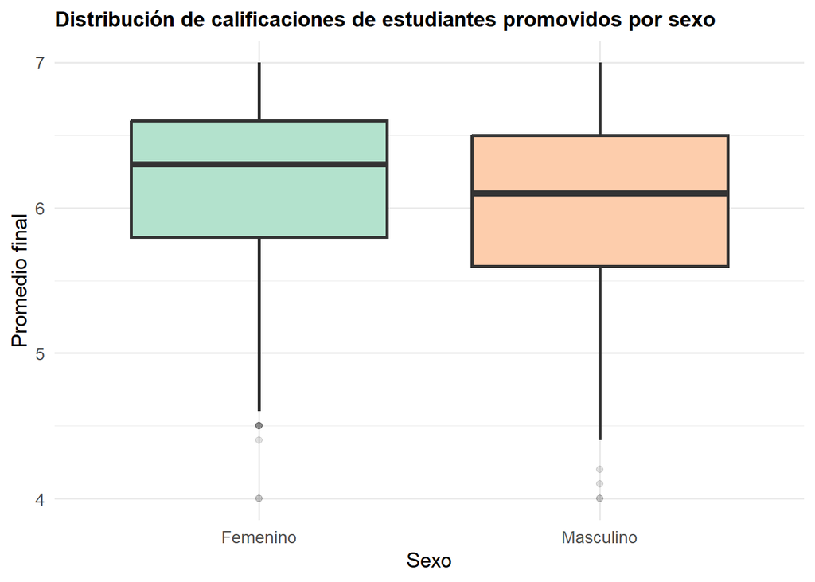

### 3.1.2 Rendimiento estudiantil por nivel formativo

Este apartado presenta estadísticos descriptivos del promedio final acumulado, solo para estudiantes promovidos, desagregados por nivel/etapa educativa (Enseñanza Básica, Ed. Media HC, Ed. Media HC adultos y Ed. Media TP), sin controlar por curso o establecimiento.

**Educación Básica combina alta promoción con promedios más altos, mientras que en Media los promedios de los promovidos son más bajos y con mayor variabilidad, especialmente en Adultos**, lo que sugiere trayectorias más heterogéneas y condiciones de aprendizaje menos estables incluso entre quienes aprueban.

En términos de gestión, esto es consistente con la evidencia previa: **el “nudo” del sistema en Educación Media no solo se expresa en mayores tasas de retiro y reprobación, sino también en un rendimiento promedio menor dentro del grupo que sí logra pasar de curso**.

Estadísticos descriptivos del promedio final por nivel: Estudiantes Promovidos

| etapa_educativa | n | media | mediana | sd | p25 | p75 | min | max |
| --- | --- | --- | --- | --- | --- | --- | --- | --- |
| Básica | 5072 | 6.13 | 6.2 | 0.54 | 5.8 | 6.6 | 4.0 | 7.0 |
| Media HC | 1609 | 5.96 | 6.0 | 0.58 | 5.5 | 6.4 | 4.2 | 7.0 |
| Media HC adultos | 213 | 5.88 | 5.9 | 0.61 | 5.5 | 6.4 | 4.1 | 6.9 |
| Media TP | 476 | 5.95 | 6.0 | 0.48 | 5.6 | 6.3 | 4.8 | 6.9 |

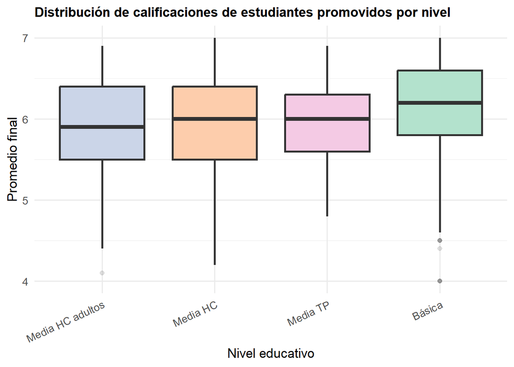

## 3.2 Indicadores de rendimiento por área del conocimiento

### 3.2.1 Nivel de educación básica

Este cuadro y gráfico presentan la distribución de calificaciones finales en Educación Básica, desagregadas por área de conocimiento, considerando todas las calificaciones registradas con valor válido, independientemente de la situación final del estudiante. Se reportan estadísticos descriptivos que permiten comparar patrones de evaluación entre áreas, más allá de trayectorias individuales.

Por otra parte, las áreas con rendimientos menores son **Lenguaje (5,67), Matemáticas (5,64), Historia (5,85), Ciencias Naturales (5,84) e Idioma Inglés (5,80)**.

**Las diferencias observadas reflejan tendencias de evaluación propios de cada área de conocimiento y no deben interpretarse directamente como diferencias de aprendizaje**; sin embargo, sí permiten identificar dónde se concentran mayores niveles de exigencia y heterogeneidad del desempeño estudiantil.

Distribución de calificaciones del nivel básico por área de conocimiento

| area_conocimiento | n | min | p25 | mediana | promedio | p75 | max | sd |
| --- | --- | --- | --- | --- | --- | --- | --- | --- |
| EDUCACIÓN FÍSICA | 4541 | 1 | 6.5 | 6.70 | 6.61 | 6.9 | 7 | 0.47 |
| ARTES | 4560 | 1 | 6.3 | 6.70 | 6.47 | 6.9 | 7 | 0.61 |
| MUSICA | 4553 | 1 | 6.2 | 6.70 | 6.45 | 6.9 | 7 | 0.68 |
| TECNOLOGIA | 4766 | 1 | 6.1 | 6.60 | 6.37 | 6.9 | 7 | 0.74 |
| LENGUA INDIGENA | 1312 | 2 | 5.8 | 6.45 | 6.24 | 6.8 | 7 | 0.73 |
| HISTORIA, GEOGRAFÍA, CIENCIAS SOCIALES | 4883 | 1 | 5.3 | 6.00 | 5.85 | 6.5 | 7 | 0.83 |
| CIENCIAS NATURALES | 4613 | 1 | 5.3 | 6.00 | 5.84 | 6.5 | 7 | 0.81 |
| IDIOMA INGLÉS | 2853 | 1 | 5.2 | 6.00 | 5.80 | 6.6 | 7 | 0.97 |
| LENGUAJE | 4582 | 1 | 5.1 | 5.80 | 5.67 | 6.3 | 7 | 0.82 |
| MATEMÁTICA | 4560 | 1 | 5.0 | 5.80 | 5.64 | 6.4 | 7 | 0.95 |

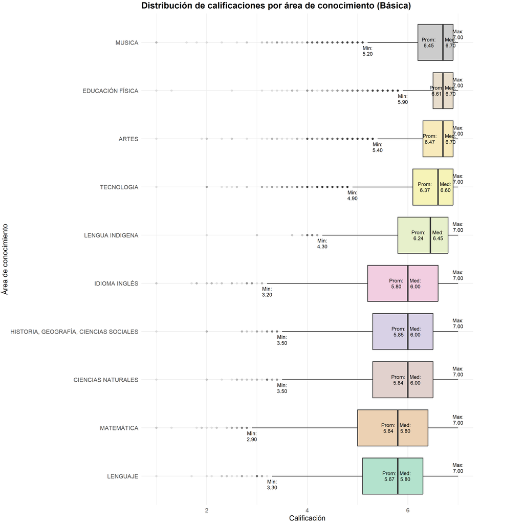

**En Lenguaje, en Educación Básica, se observa una brecha leve pero consistente a favor de las estudiantes mujeres**, con una mediana de 6,1 frente a 5,8 en los hombres y un promedio ligeramente superior (5,9 vs. 5,7). Esta diferencia se mantiene a lo largo de la distribución, desde el percentil 25 (5,4 vs. 5,1) hasta el percentil 75 (6,5 vs. 6,4), sin evidenciar contrastes relevantes en la dispersión (desviaciones estándar cercanas a 0,8–0,9). El patrón sugiere un **mejor desempeño femenino generalizado, asociado a un desplazamiento moderado del nivel central más que a diferencias en la variabilidad del rendimiento**.

Estadísticos descriptivos de rendimiento en Lenguaje por sexo: Educación Básica

| SEXO | n | min | p25 | mediana | promedio | p75 | max | sd |
| --- | --- | --- | --- | --- | --- | --- | --- | --- |
| Femenino | 2799 | 1.0 | 5.4 | 6.1 | 5.9 | 6.5 | 7 | 0.80 |
| Masculino | 3143 | 1.7 | 5.1 | 5.8 | 5.7 | 6.4 | 7 | 0.86 |

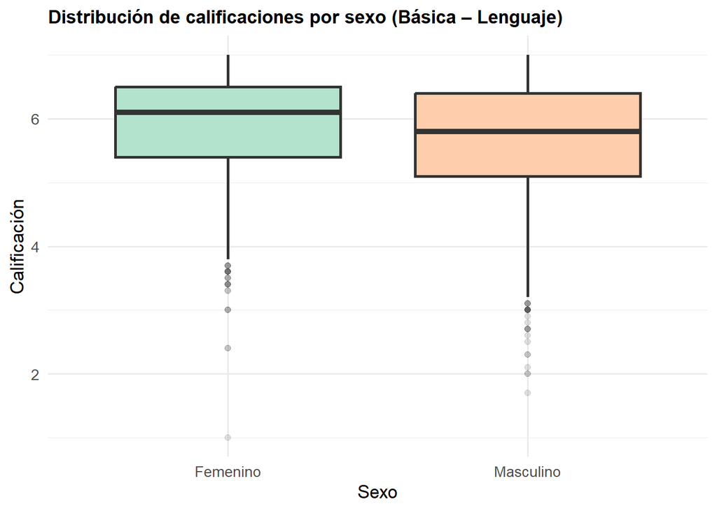

**En Matemática, en Educación Básica, no se observan diferencias sustantivas de rendimiento por sexo**. Las medianas son idénticas en ambos grupos (5,8), y los promedios resultan prácticamente equivalentes (5,66 en mujeres y 5,63 en hombres). Asimismo, los percentiles 25 y 75 muestran valores muy similares, lo que indica una alta superposición de las distribuciones. La dispersión también es comparable entre sexos (desviación estándar cercana a 0,95), sugiriendo que, a diferencia de lo observado en Lenguaje en este mismo nivel, el **rendimiento en Matemática durante la Educación Básica se distribuye de manera homogénea entre estudiantes mujeres y hombres**, sin configurar una brecha sistemática por sexo.

Estadísticos descriptivos de rendimiento en Matemática por sexo: Educación Básica

| SEXO | n | min | p25 | mediana | promedio | p75 | max | sd |
| --- | --- | --- | --- | --- | --- | --- | --- | --- |
| Femenino | 2143 | 1 | 5.1 | 5.8 | 5.66 | 6.4 | 7 | 0.94 |
| Masculino | 2417 | 1 | 5.0 | 5.8 | 5.63 | 6.4 | 7 | 0.95 |

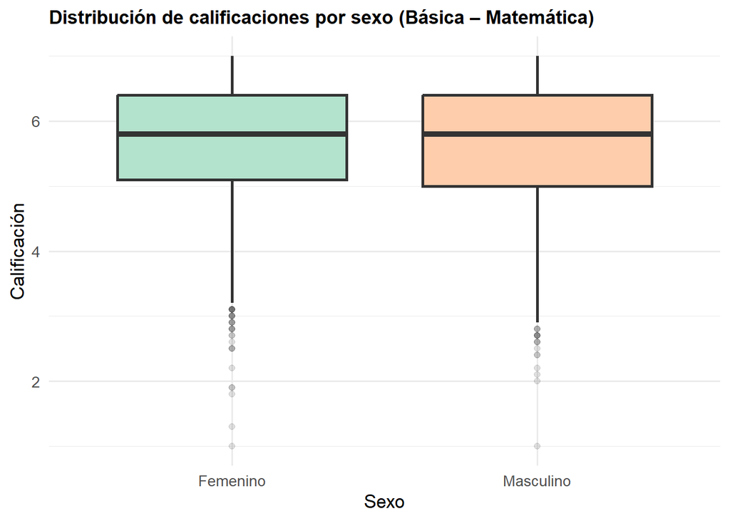

### 3.2.2 Nivel de educación media HC

Este sub-apartado muestra la distribución de calificaciones finales en Enseñanza Media Humanista-Científica Regular, desagregadas por área de conocimiento, considerando todas las calificaciones registradas, independientemente de la situación de repitencia o aprobación del estudiante.

Las áreas con **promedios más altos en Enseñanza Media HC corresponden principalmente a asignaturas formativas, expresivas, electivas o de especialización**, destacando Música (6,55), Arquitectura (6,53), Educación Física (6,35), Artes (6,24) y Tecnología (6,02). Además, estas áreas presentan menor dispersión relativa, lo que indica una mayor concentración de calificaciones en torno a valores altos.

Por el contrario, **las áreas instrumentales y científicas registran los promedios más bajos**, particularmente Matemática (5,32), Lenguaje (5,58), Ciencias Naturales (5,43) y Ciencias Físicas (5,00). En estos casos, **las distribuciones muestran una mayor dispersión interna y una presencia más marcada de calificaciones bajas**.

Distribución de calificaciones del nivel Medio por área de conocimiento

| area_conocimiento | n | min | p25 | mediana | promedio | p75 | max | sd |
| --- | --- | --- | --- | --- | --- | --- | --- | --- |
| OTRAS ASIGNATURAS HUMANISTAS | 2040 | 1.0 | 5.60 | 6.2 | 6.08 | 6.70 | 7.0 | 0.80 |
| MATEMÁTICA | 1759 | 1.0 | 4.50 | 5.3 | 5.32 | 6.30 | 7.0 | 1.13 |
| LENGUAJE | 1743 | 1.0 | 4.90 | 5.7 | 5.58 | 6.40 | 7.0 | 0.95 |
| IDIOMA INGLÉS | 1658 | 1.0 | 5.30 | 6.1 | 5.87 | 6.70 | 7.0 | 0.97 |
| HISTORIA, GEOGRAFÍA, CIENCIAS SOCIALES | 1168 | 2.6 | 5.20 | 5.9 | 5.75 | 6.50 | 7.0 | 0.95 |
| CIENCIAS NATURALES | 1035 | 2.0 | 4.80 | 5.4 | 5.43 | 6.10 | 7.0 | 0.86 |
| TECNOLOGIA | 972 | 1.7 | 5.57 | 6.3 | 6.02 | 6.70 | 7.0 | 0.90 |
| EDUCACIÓN FÍSICA | 717 | 1.0 | 6.10 | 6.6 | 6.35 | 6.90 | 7.0 | 0.74 |
| ARTES | 628 | 3.1 | 5.80 | 6.4 | 6.24 | 6.90 | 7.0 | 0.74 |
| MUSICA | 376 | 2.5 | 6.30 | 6.8 | 6.55 | 7.00 | 7.0 | 0.68 |
| SALUD | 114 | 1.0 | 6.00 | 6.5 | 6.26 | 6.90 | 7.0 | 0.89 |
| CIENCIAS BIOLOGICAS | 105 | 1.0 | 5.40 | 6.1 | 5.93 | 6.60 | 7.0 | 0.90 |
| ARQUITECTURA | 46 | 4.0 | 6.30 | 6.7 | 6.53 | 7.00 | 7.0 | 0.60 |
| CIENCIAS QUÍMICAS | 30 | 4.6 | 5.60 | 6.1 | 5.92 | 6.47 | 7.0 | 0.74 |
| CIENCIAS FÍSICAS | 15 | 3.7 | 4.40 | 4.9 | 5.00 | 5.35 | 6.9 | 0.88 |

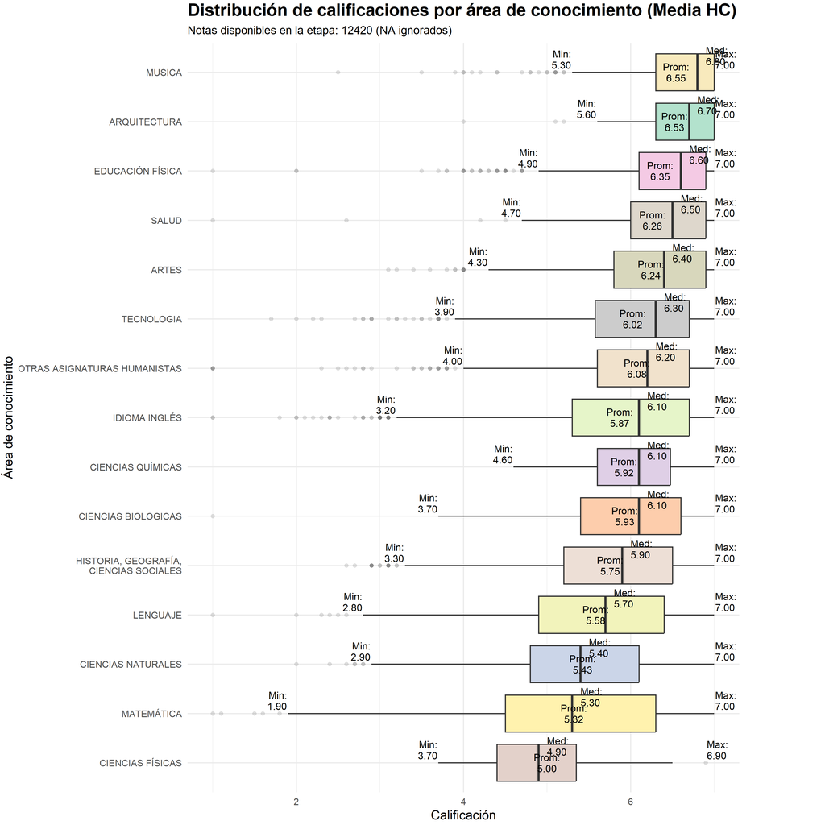

**En Lenguaje (Media HC) se identifica una brecha sistemática a favor de las mujeres**, con medianas y promedios superiores (mediana: 5,9 vs. 5,4; promedio: 5,76 vs. 5,40). Esta diferencia se mantiene a lo largo de toda la distribución, desde el percentil 25 hasta el 75, sin evidenciar mayores contrastes en la dispersión. El patrón observado responde, por tanto, a un **mejor rendimiento relativo femenino más que a diferencias en la variabilidad de las calificaciones**.

Estadísticos descriptivos de rendimiento en Lenguaje por sexo: Educación Media HC

| SEXO | n | min | p25 | mediana | promedio | p75 | max | sd |
| --- | --- | --- | --- | --- | --- | --- | --- | --- |
| Femenino | 882 | 2.3 | 5.1 | 5.9 | 5.76 | 6.5 | 7 | 0.91 |
| Masculino | 861 | 1.0 | 4.7 | 5.4 | 5.40 | 6.2 | 7 | 0.96 |

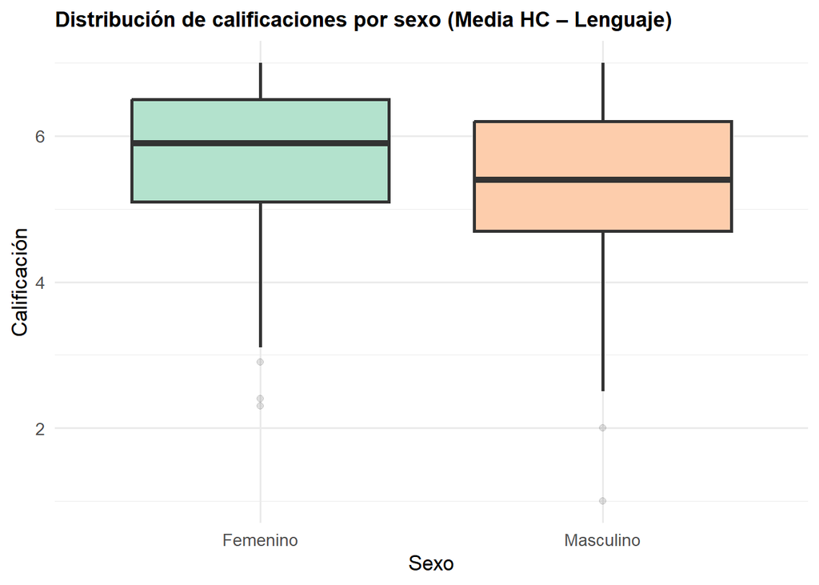

**En Matemática (Media HC), se observa una brecha moderada a favor de las estudiantes mujeres**, con medianas y promedios levemente superiores (mediana: 5,5 vs. 5,1; promedio: 5,42 vs. 5,22). Esta diferencia se mantiene a lo largo de la distribución, desde el percentil 25 hasta el 75, aunque con una mayor dispersión de los resultados, particularmente en el grupo masculino. En comparación con Lenguaje, **la brecha por sexo en Matemática es menos pronunciada y presenta una superposición más amplia entre distribuciones**, lo que sugiere un desplazamiento del nivel central más acotado y una mayor heterogeneidad del rendimiento.

Estadísticos descriptivos de rendimiento en Matemática por sexo: Educación Media HC

| SEXO | n | min | p25 | mediana | promedio | p75 | max | sd |
| --- | --- | --- | --- | --- | --- | --- | --- | --- |
| Femenino | 877 | 1.8 | 4.7 | 5.5 | 5.42 | 6.4 | 7 | 1.09 |
| Masculino | 882 | 1.0 | 4.4 | 5.1 | 5.22 | 6.2 | 7 | 1.16 |

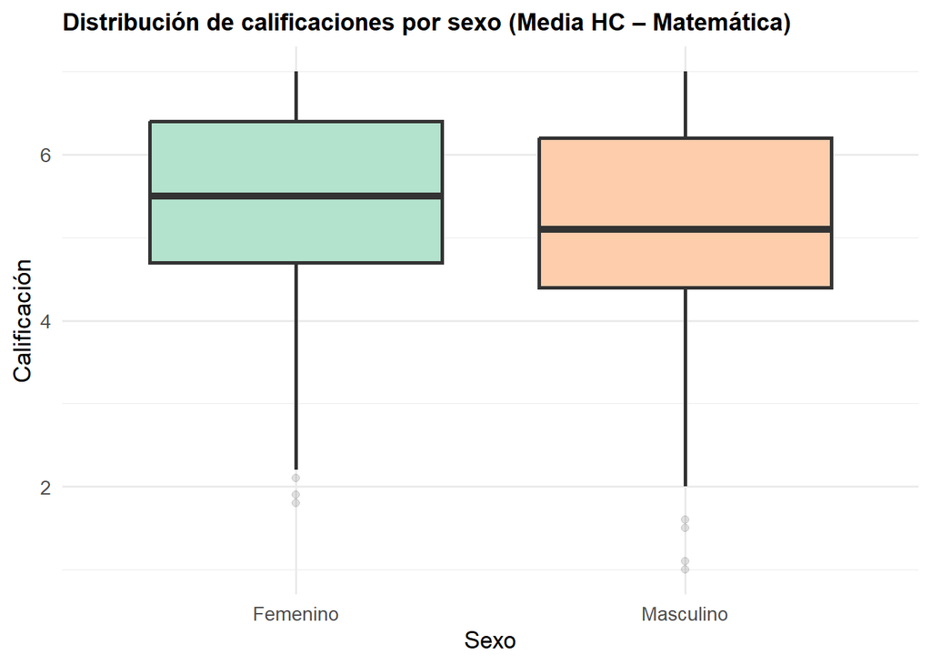

### 3.2.3 Media HC-Adultos

Este sub-apartado muestra la distribución de calificaciones finales en Enseñanza Media Humanista-Científica de adultos, desagregadas por área de conocimiento, considerando todas las calificaciones registradas con valor válido.

Por el contrario, **las áreas instrumentales y científicas muestran promedios más bajos**, especialmente Ciencias Naturales (5,41), Matemática (5,36), Lenguaje (5,42) e Idioma Inglés (5,53). En estos casos, las distribuciones presentan mayor dispersión interna, con colas inferiores más extensas y valores mínimos significativamente más bajos que en otras áreas.

Distribución de calificaciones del nivel Medio de adultos por área de conocimiento

| area_conocimiento | n | min | p25 | mediana | promedio | p75 | max | sd |
| --- | --- | --- | --- | --- | --- | --- | --- | --- |
| OTRAS ASIGNATURAS HUMANISTAS | 239 | 1.0 | 5.55 | 6.1 | 5.85 | 6.60 | 7 | 1.06 |
| CIENCIAS NATURALES | 228 | 1.0 | 4.80 | 5.6 | 5.41 | 6.20 | 7 | 1.11 |
| MATEMÁTICA | 223 | 1.0 | 4.55 | 5.7 | 5.36 | 6.30 | 7 | 1.25 |
| IDIOMA INGLÉS | 212 | 1.0 | 4.90 | 5.7 | 5.53 | 6.40 | 7 | 1.17 |
| LENGUAJE | 212 | 1.0 | 4.97 | 5.7 | 5.42 | 6.12 | 7 | 1.08 |
| COMPETENCIAS TRANSVERSALES | 195 | 1.0 | 5.30 | 6.3 | 5.82 | 6.75 | 7 | 1.32 |
| CUIDADOS | 106 | 2.5 | 5.23 | 6.1 | 5.88 | 6.70 | 7 | 1.05 |
| INFORMÁTICA | 64 | 1.9 | 5.68 | 6.3 | 5.99 | 6.70 | 7 | 1.06 |
| EDUCACIÓN FÍSICA | 17 | 1.0 | 6.60 | 6.8 | 6.33 | 7.00 | 7 | 1.54 |

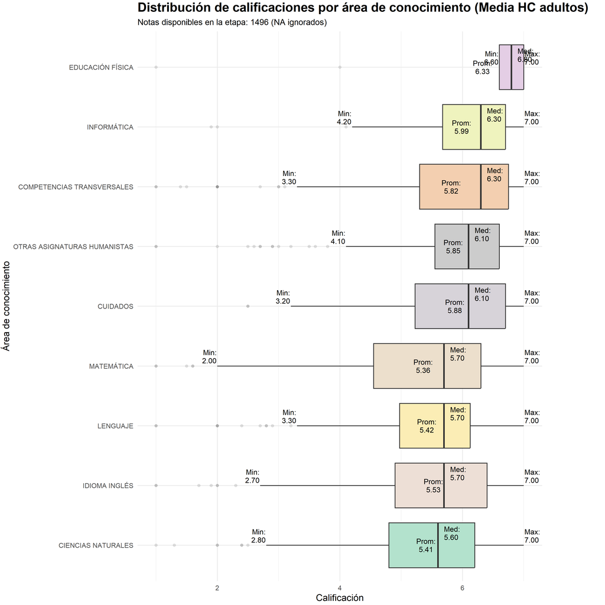

**En Lenguaje, en Educación Media HC adultos, se observa una brecha marcada a favor de las estudiantes mujeres**, con diferencias relevantes tanto en la mediana (6,25 en mujeres frente a 5,50 en hombres) como en el promedio (6,00 vs. 5,31). Esta brecha se manifiesta a lo largo de toda la distribución, desde el percentil 25 (5,70 vs. 4,77) hasta el percentil 75 (6,60 vs. 6,00), y se acompaña de una mayor dispersión en el grupo masculino. Si bien **los tamaños muestrales son más acotados que en otros niveles, el patrón observado sugiere un mejor desempeño femenino consistente** y una mayor heterogeneidad de resultados entre los hombres en esta área y modalidad.

Estadísticos descriptivos de rendimiento en Lenguaje por sexo: Educación Media HC Adultos

| SEXO | n | min | p25 | mediana | promedio | p75 | max | sd |
| --- | --- | --- | --- | --- | --- | --- | --- | --- |
| Femenino | 96 | 1.9 | 5.70 | 6.25 | 6.00 | 6.6 | 7 | 0.92 |
| Masculino | 180 | 1.0 | 4.77 | 5.50 | 5.31 | 6.0 | 7 | 1.12 |

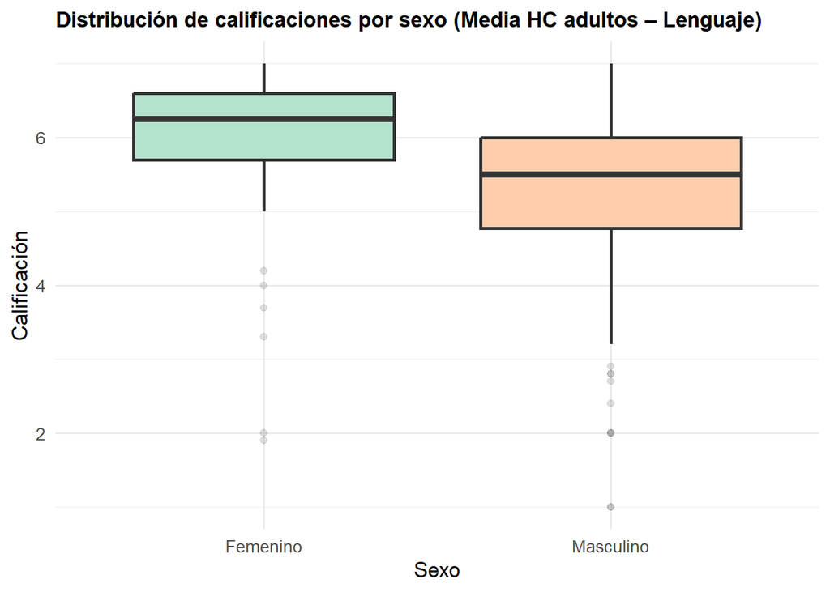

**En Matemática, en Educación Media HC adultos, se observa una brecha a favor de las estudiantes mujeres**, con medianas y promedios superiores (mediana: 6,0 vs. 5,5; promedio: 5,7 vs. 5,2). Esta diferencia se mantiene a lo largo de la distribución, desde el percentil 25 (5,23 vs. 4,50) hasta el percentil 75 (6,47 vs. 6,20), y se acompaña de una mayor dispersión en el grupo masculino. Al igual que en Lenguaje, y considerando tamaños muestrales más reducidos, **el patrón sugiere un mejor desempeño femenino consistente y una mayor heterogeneidad del rendimiento entre los hombres en esta modalidad**.

Estadísticos descriptivos de rendimiento en Matemática por sexo: Educación Media HC Adultos

| SEXO | n | min | p25 | mediana | promedio | p75 | max | sd |
| --- | --- | --- | --- | --- | --- | --- | --- | --- |
| Femenino | 70 | 1.6 | 5.23 | 6.0 | 5.7 | 6.47 | 7 | 1.07 |
| Masculino | 153 | 1.0 | 4.50 | 5.5 | 5.2 | 6.20 | 7 | 1.30 |

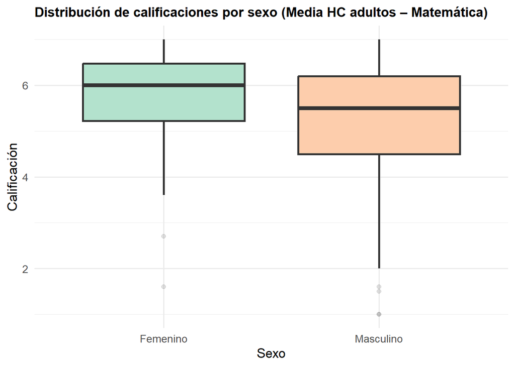

### 3.2.4 Media TP

Este apartado presenta la distribución de calificaciones finales en Enseñanza Media Técnico-Profesional, desagregadas por área de conocimiento, considerando todas las calificaciones registradas con valor válido, independientemente de la situación final del estudiante.

En términos generales, **las áreas técnico-profesionales específicas y las asignaturas formativas presentan promedios relativamente altos**, destacando Música (6,56), Educación Física (6,42), Turismo (6,35), Mecánica (6,25), Artes (6,13) y Electricidad (6,13). Estas áreas muestran distribuciones más concentradas en torno a calificaciones altas, con medianas cercanas o superiores a 6,0.

Por el contrario, **las áreas instrumentales y científico-académicas registran los promedios más bajos**, particularmente Ciencias Naturales (4,73), Lenguaje (5,56), Matemática (5,62) y Producción Acuícola (5,69). En estos casos, se observan colas inferiores extensas y valores mínimos considerablemente más bajos, lo que evidencia mayores dificultades de desempeño para una parte relevante del estudiantado.

En contraste, **las áreas técnico-productivas (Electricidad, Mecánica, Informática, Industrial, Alimentos) tienden a mostrar medianas más altas y distribuciones algo más compactas**, lo que podría reflejar criterios de evaluación más aplicados, contextualizados y alineados con competencias prácticas, favoreciendo trayectorias de logro más homogéneas.

Distribución de calificaciones del nivel Medio TP por área de conocimiento

| area_conocimiento | n | min | p25 | mediana | promedio | p75 | max | sd |
| --- | --- | --- | --- | --- | --- | --- | --- | --- |
| OTRAS ASIGNATURAS HUMANISTAS | 1124 | 2.4 | 5.40 | 6.00 | 5.91 | 6.50 | 7.0 | 0.78 |
| IDIOMA INGLÉS | 487 | 3.1 | 5.30 | 5.90 | 5.78 | 6.40 | 7.0 | 0.78 |
| MATEMÁTICA | 436 | 2.8 | 5.10 | 5.75 | 5.62 | 6.30 | 7.0 | 0.87 |
| LENGUAJE | 427 | 3.1 | 5.00 | 5.60 | 5.56 | 6.10 | 7.0 | 0.75 |
| SALUD | 377 | 4.1 | 5.60 | 6.10 | 6.02 | 6.50 | 7.0 | 0.65 |
| EMPRESAS Y ADMINISTRACIÓN | 355 | 4.0 | 5.70 | 6.20 | 6.08 | 6.50 | 7.0 | 0.56 |
| EDUCACIÓN FÍSICA | 272 | 4.3 | 6.20 | 6.60 | 6.42 | 6.90 | 7.0 | 0.59 |
| HISTORIA, GEOGRAFÍA, CIENCIAS SOCIALES | 216 | 2.0 | 5.00 | 5.70 | 5.60 | 6.30 | 7.0 | 0.90 |
| INDUSTRIAL | 212 | 4.0 | 5.80 | 6.30 | 6.16 | 6.60 | 7.0 | 0.54 |
| ALIMENTOS | 171 | 3.3 | 5.70 | 6.20 | 6.05 | 6.60 | 7.0 | 0.64 |
| MECÁNICA | 136 | 5.3 | 6.07 | 6.20 | 6.25 | 6.50 | 6.9 | 0.35 |
| INFORMÁTICA | 124 | 3.8 | 5.60 | 6.10 | 5.98 | 6.40 | 7.0 | 0.57 |
| CUIDADOS | 118 | 3.6 | 5.70 | 6.15 | 6.06 | 6.50 | 7.0 | 0.56 |
| ARTES | 115 | 2.9 | 5.60 | 6.40 | 6.13 | 7.00 | 7.0 | 0.96 |
| ELECTRICIDAD | 112 | 4.9 | 5.80 | 6.20 | 6.13 | 6.50 | 7.0 | 0.51 |
| TECNOLOGIA | 98 | 4.1 | 5.70 | 6.10 | 6.04 | 6.50 | 7.0 | 0.59 |
| CIENCIAS NATURALES | 98 | 2.4 | 4.00 | 4.70 | 4.73 | 5.50 | 6.8 | 0.97 |
| MUSICA | 64 | 5.1 | 6.40 | 6.70 | 6.56 | 6.90 | 7.0 | 0.42 |
| TURISMO | 58 | 4.7 | 6.20 | 6.40 | 6.35 | 6.60 | 7.0 | 0.40 |
| COMPETENCIAS TRANSVERSALES | 38 | 4.0 | 5.80 | 6.35 | 6.17 | 6.60 | 7.0 | 0.67 |
| PRODUCCIÓN ACUICOLA | 36 | 3.2 | 5.27 | 5.75 | 5.69 | 6.40 | 6.9 | 0.92 |
| MINERÍA | 18 | 4.1 | 5.20 | 5.60 | 5.57 | 5.97 | 6.3 | 0.56 |

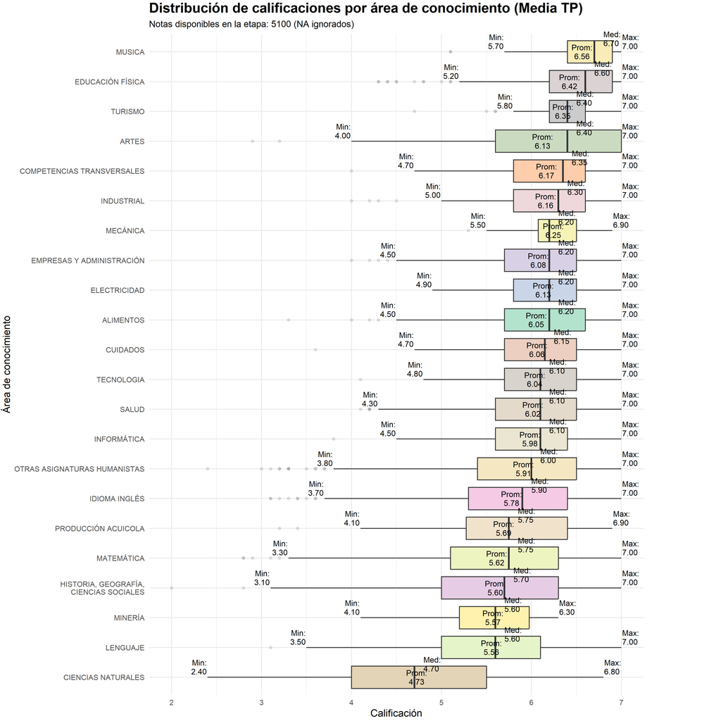

**En Lenguaje, en Educación Media TP, se identifica una brecha leve a favor de las estudiantes mujeres**, con una mediana de 5,9 frente a 5,7 en los hombres y un promedio ligeramente superior (5,87 vs. 5,59). Esta diferencia se mantiene en los percentiles inferiores y superiores de la distribución (p25: 5,4 vs. 5,1; p75: 6,4 vs. 6,2), aunque con una mayor dispersión en el grupo masculino. En conjunto, el patrón sugiere un **mejor desempeño femenino moderado, sin configurar diferencias de gran magnitud**, pero consistente a lo largo de la distribución.

Estadísticos descriptivos de rendimiento en Lenguaje por sexo: Educación Media TP

| SEXO | n | min | p25 | mediana | promedio | p75 | max | sd |
| --- | --- | --- | --- | --- | --- | --- | --- | --- |
| Femenino | 248 | 3.8 | 5.4 | 5.9 | 5.87 | 6.4 | 7 | 0.66 |
| Masculino | 336 | 3.1 | 5.1 | 5.7 | 5.59 | 6.2 | 7 | 0.78 |

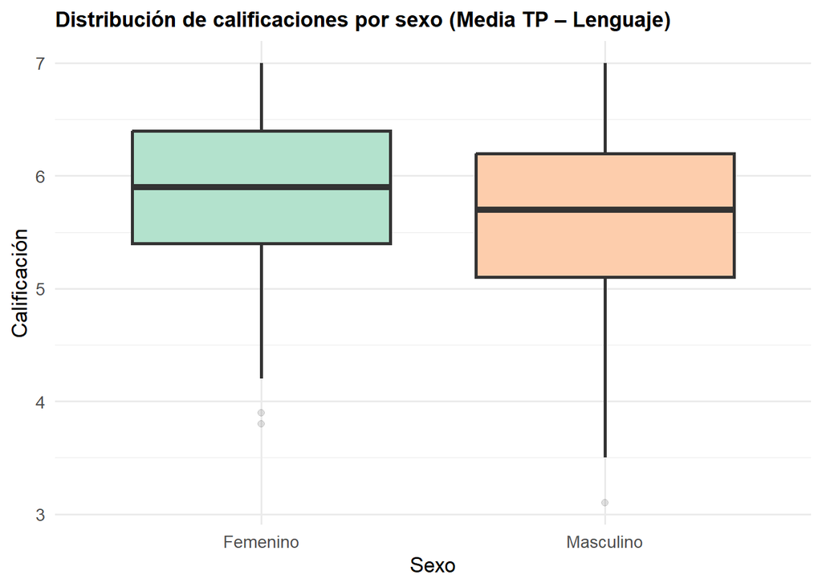

**En Matemática, en Educación Media TP, se observa una brecha moderada a favor de las estudiantes mujeres**, con una mediana de 5,9 frente a 5,5 en los hombres y un promedio superior (5,83 vs. 5,42). Esta diferencia se mantiene a lo largo de la distribución, desde el percentil 25 (5,3 vs. 4,7) hasta el percentil 75 (6,4 vs. 6,2), y se acompaña de una mayor dispersión en el grupo masculino (desviación estándar 0,92, frente a 0,75 en mujeres). El patrón sugiere un **mejor desempeño femenino consistente, junto con una mayor heterogeneidad de resultados entre los estudiantes hombres en esta área** y nivel educativo.

Estadísticos descriptivos de rendimiento en Matemática por sexo: Educación Media TP

| SEXO | n | min | p25 | mediana | promedio | p75 | max | sd |
| --- | --- | --- | --- | --- | --- | --- | --- | --- |
| Femenino | 208 | 3.3 | 5.3 | 5.9 | 5.83 | 6.4 | 7 | 0.75 |
| Masculino | 228 | 2.8 | 4.7 | 5.5 | 5.42 | 6.2 | 7 | 0.92 |

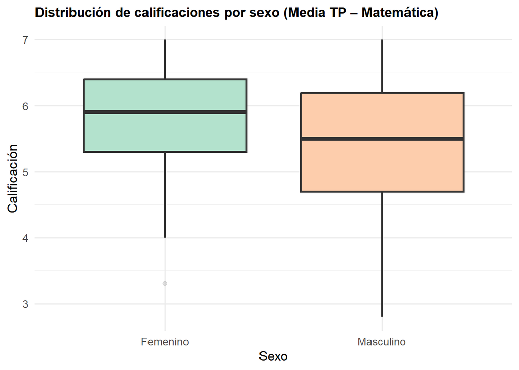

## 3.3 Impacto de la asistencia en el rendimiento

### 3.3.1 Tabla de estadísticas correlacionales

Esta tabla presenta la relación estadística entre la asistencia escolar y el rendimiento académico, estimada separadamente para cada etapa educativa. Su objetivo es **examinar hasta qué punto las variables de asistencia y promedio final tienden a variar juntas: es decir, si estudiantes con mayor asistencia tienden a tener también mejores calificaciones**.

La correlación es un **indicador estadístico que mide la fuerza y dirección de la relación entre estas dos variables**, donde los valores pueden ir de -1 a +1. Un valor positivo indica una relación positiva entre ambas variables (mayor asistencia, mayor promedio) y uno negativo indica una relación negativa (mayor asistencia, menor promedio). Valores cercanos a 0, sean positivos o negativos, indican una relación débil o inexistente.

En la siguiente tabla se muestran dos indicadores de correlación: Pearson y Spearman: - El coeficiente de Pearson compara los valores originales obtenidos por cada estudiante caso a caso. - El coeficiente de Spearman, en cambio, compara el orden relativo de los estudiantes, no sus valores exactos. - Ambas estrategias se triangularon para obtener resultados más confiables. Los valores similares obtenidos por cada uno de estos coeficientes indican que las correlaciones identificadas sí son relevantes y válidas.

Finalmente, la significancia estadística (expresada como *** en la tabla) es una medida de validez de los resultados obtenidos: un resultado es significativo cuando puede garantizarse que se ha producido por tendencias reales en los datos y no por el azar. **En la tabla de correlación, podemos corroborar que todos los resultados obtenidos son estadísticamente significativos**.

Correlación entre asistencia y rendimiento académico

| etapa_educativa | n | Pearson (r) | Spearman (ρ) | media_prom | media_asis |
| --- | --- | --- | --- | --- | --- |
| Básica | 5194 | 0.317*** | 0.228*** | 6.09 | 85.9% |
| Media HC | 1683 | 0.422*** | 0.350*** | 5.88 | 84.4% |
| Media HC adultos | 232 | 0.569*** | 0.507*** | 5.64 | 67.0% |
| Media TP | 490 | 0.355*** | 0.348*** | 5.91 | 84.5% |

### 3.3.2 Asistencia y rendimiento académico en el nivel básico

Los resultados muestran una **correlación positiva y estadísticamente significativa entre asistencia y rendimiento académico en el nivel de educación básica**. El coeficiente de Pearson (r = 0,317) indica una relación lineal moderada, mientras que el coeficiente de Spearman (ρ = 0,228) confirma que, en términos generales, los estudiantes con mayor asistencia tienden a ubicarse entre quienes obtienen mejores promedios, aunque con una intensidad más acotada cuando se observa el orden relativo.

En el gráfico se observa una tendencia ascendente clara, donde **los promedios más altos se concentran mayoritariamente en niveles de asistencia elevados (sobre 80–85%)**. Sin embargo, también se aprecia una amplia dispersión de calificaciones a lo largo del eje de asistencia, especialmente en tramos intermedios, lo que indica que **la asistencia, aunque relevante, no explica por sí sola el rendimiento académico**.

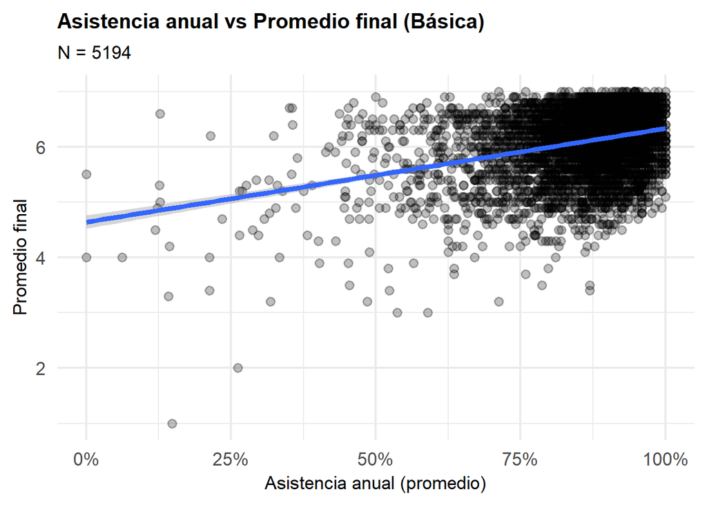

### 3.3.3 Asistencia y rendimiento académico en el nivel medio

Los resultados muestran **en el nivel medio HC regular, una correlación positiva, estadísticamente significativa y más intensa que en Educación Básica**. El coeficiente de Pearson (r = 0,422) indica una relación lineal moderada-alta, mientras que el coeficiente de Spearman (ρ = 0,350) confirma que los estudiantes con mayor asistencia tienden sistemáticamente a ubicarse entre quienes obtienen mejores promedios finales. La cercanía entre ambos valores refuerza la consistencia de esta asociación.

El gráfico muestra un patrón ascendente más definido que en Básica. **A medida que aumenta la asistencia, se observa un incremento claro en los promedios finales, con una mayor concentración de calificaciones altas en tramos de asistencia elevados (sobre 80–85%)**. Al mismo tiempo, la dispersión de notas en niveles bajos de asistencia es más amplia, lo que sugiere que **en este nivel, la inasistencia tiene un efecto más claramente asociado al bajo rendimiento en este nivel educativo**.

Estos resultados indican que **en la Educación Media HC la asistencia adquiere un rol más estructurante del rendimiento académico. A diferencia de Básica, donde la relación es más habilitante, en Media HC la presencia regular en el aula parece estar más estrechamente vinculada al logro académico**, posiblemente debido a una mayor acumulación de contenidos, exigencias y menor posibilidad de compensación frente a inasistencias prolongadas.

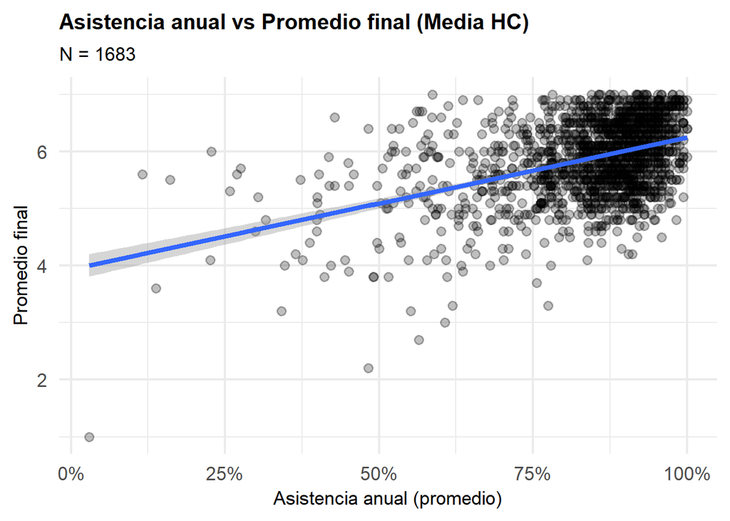

### 3.3.4 Asistencia y rendimiento académico en el nivel medio de adultos

**Los resultados muestran la correlación más alta de todo el sistema educativo analizado**. El coeficiente de Pearson (r = 0,569) indica una relación positiva fuerte, mientras que el coeficiente de Spearman (ρ = 0,507) confirma que los estudiantes con mayor asistencia tienden de manera muy consistente a ubicarse entre quienes obtienen mejores promedios finales. **La magnitud y cercanía entre ambos coeficientes refuerzan la relevancia de esta tendencia, aun considerando el menor tamaño muestral**.

**El gráfico de dispersión presenta un patrón ascendente claro y concentrado, con una pendiente más pronunciada que en Básica y Media HC regular**. A medida que aumenta la asistencia, los promedios finales crecen de forma sostenida, mientras que **los niveles bajos de asistencia se asocian con una alta dispersión y con los promedios más bajos del conjunto**. **La relación entre ambas variables es visual y estadísticamente muy nítida**.

**Este resultado sugiere que en la modalidad de adultos la asistencia opera como un factor altamente estructurante del rendimiento académico**. Dado que se trata de trayectorias educativas más comprimidas y con estudiantes que suelen compatibilizar estudio, trabajo y responsabilidades familiares, la presencia en el aula se vuelve un determinante central del logro académico.

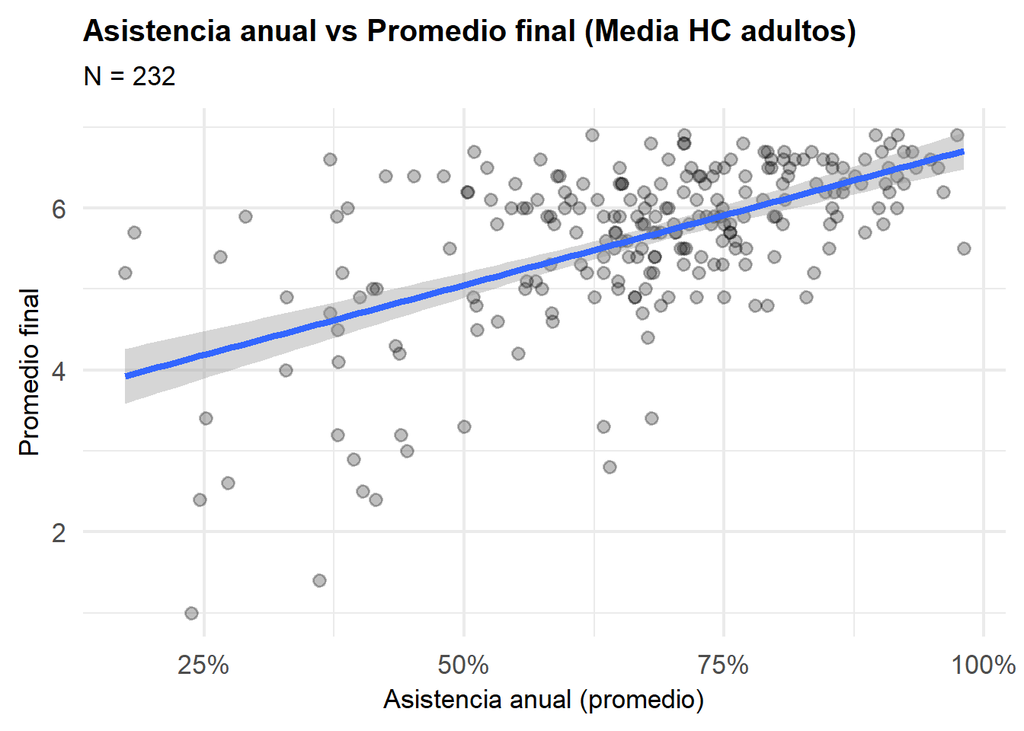

### 3.3.5 Asistencia y rendimiento académico en el nivel TP

Los resultados muestran una **correlación positiva y estadísticamente significativa, de magnitud moderada**. El coeficiente de Pearson (r = 0,355) indica una relación lineal clara entre asistencia y rendimiento, mientras que el coeficiente de Spearman (ρ = 0,348) confirma que los estudiantes con mayor asistencia tienden consistentemente a ubicarse entre quienes obtienen mejores promedios finales.

**El gráfico presenta una tendencia ascendente definida, aunque con una dispersión mayor que en Media HC adultos y menor que en Educación Básica**. Los promedios más altos se concentran principalmente en niveles de asistencia elevados (sobre 80%), mientras que **los tramos de asistencia media y baja exhiben una mayor heterogeneidad en el rendimiento, incluyendo promedios relativamente altos y bajos**.

Estos resultados sugieren que en la Educación Media TP la asistencia cumple un rol relevante, pero no exclusivo en el desempeño académico.

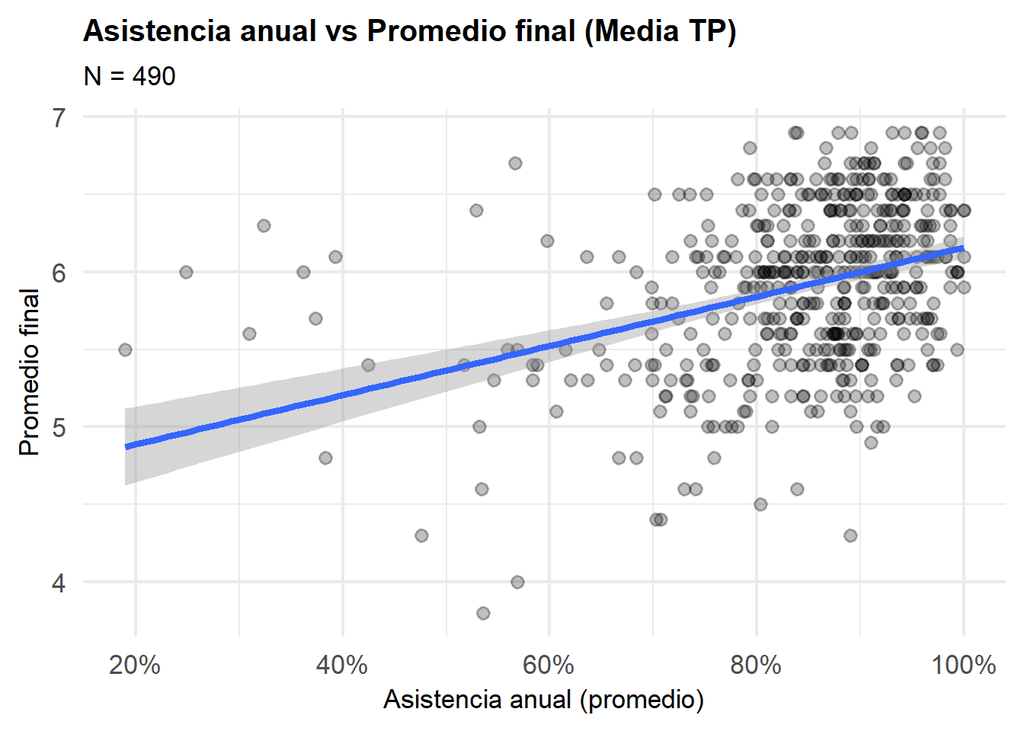

# 4 Sobre las fuentes de información

Para disponer de información sistemática y comparable sobre las actas de calificaciones y las asignaturas impartidas en los establecimientos del Servicio Local, se implementó un procedimiento de obtención y organización de estos datos. Dado que esta información se encuentra distribuida en múltiples documentos individuales (actas por establecimiento, curso y período), el primer paso consistió en descargar de manera ordenada todas las actas oficiales disponibles, asegurando que correspondieran al año escolar y a los niveles educativos de interés. Este proceso permitió reunir, en un único repositorio, la totalidad de los documentos que respaldan formalmente los resultados académicos de los estudiantes.

Recopiladas las actas, se desarrolló un proceso de sistematización que permitió transformar estos documentos —originalmente en formato PDF— en bases de datos estructuradas. Para ello, se identificaron los elementos clave presentes en las actas, tales como establecimiento, nivel, curso, asignatura, docente responsable y tabl de calificaciones obtenidas. Esta etapa fue fundamental para pasar desde información fragmentada y no-comparable a un conjunto de datos ordenados que puede ser analizado de manera transversal entre establecimientos, niveles educativos y áreas de conocimiento.

Finalmente, la información extraída fue integrada en archivos de trabajo estandarizados, lo que facilita su uso posterior en análisis institucionales, informes de seguimiento y toma de decisiones pedagógicas. Esto permitió aprovechar información que ya existía en los sistemas oficiales, además de fortalecer su uso con fines analíticos, asegurando trazabilidad, coherencia y comparabilidad entre establecimientos del territorio.

Si desea mayor información sobre la descarga y procesamiento de estos datos, puede escribir a **enzo.zurita@slepaysen.cl**. Si desea acceder a las tablas de datos utilizadas para calcular los indicadores presentados en este reporte, puedes descargar sus archivos excel en los siguientes recuadros:

Asistencia (DEP-SIGE)

Base original utilizada calcular asistencia 2025.

[Descargar Excel](https://slepaysen-my.sharepoint.com/:x:/g/personal/enzo_zurita_slepaysen_cl/IQCox4hbtXjkSbpkc33OOaEXAaiBGatYeTltFWnKLzjXEVU?e=aV0USf)

Estudiantes (Actas 2025)

Base original de calificaciones y situación final.

[Descargar Excel](https://slepaysen-my.sharepoint.com/:x:/g/personal/enzo_zurita_slepaysen_cl/IQBWtD6MP3zzTbFHfyqdg9TeAT9PZepvWXhNW2GjtJN8sIM?e=wfGmU8)

Docencia (Docentes 2025)

Base original de asignaturas/áreas y docentes.

[Descargar Excel](https://slepaysen-my.sharepoint.com/:x:/g/personal/enzo_zurita_slepaysen_cl/IQD6oyeH_FWsQY2naFkItn2zAZiQ_9WUL79XJIQzhZiyY0s?e=YGMQ98)